# README

### Questão 1:

*Quais variantes deverão ser desconsideradas no seu VCF?* *Qualquer métrica do software de escolha poderá ser utilizada. Discorra sobre a métrica utilizada. Mandar o vcf filtrado*

**Resposta: No Dia 1, variantes que não passaram por filtros mínimos de qualidade recomendados pelo GATK (links abaixo) tais como qualidade de mapeamento (MQ), viés de alinhamento em uma determinada fita de DNA (FS e SOR), dentre outros, foram eliminadas. Hoje, variantes em regiões não cobertas pelo arquivo .bed foram excluídas utilizando a ferramenta bedtools (filterVCF.sh)**  
**A métrica MQ quantifica a qualidade de mapeamento de uma leitura em uma região genômica, um alto MQ assegura uma confiança no mapeamento das leituras que suportam determinada variante**  
**Métricas como FS e SOR estão relacionadas ao viés de alinhamento de reads em uma determinada fita de DNA, positiva ou negativa. Espera-se que a distribuição do alinhamento das leituras seja similar entre as fitas. Uma preferência elevada pela fita positiva ou negativa pode indicar viés do sequenciamento, como uma baixa qualidade da base sequenciada.**  
**A métrica DP representa o número de reads totais que suportam a variante, ou seja, que mapeiam na região que a variante foi identificada. Algumas variantes apresentaram valores de DP=2, o que representam duas reads mapeando na região da variante. Caso uma dessas leituras não estivesse presente a variante nem seria detectada. A maior confiabilidade da variante está relacionada a valores superiores a um valor de corte. Contudo, esse valor de corte é subjetivo. Na figura abaixo foram traçados dois cortes que separam as variantes em três categorias de confiabilidade: ruim, ok, e ótima.**  
[Filtrando variantes](https://gatk.broadinstitute.org/hc/en-us/articles/360035890471-Hard-filtering-germline-short-variants)  
[Filtrando variantes - cont](https://gatk.broadinstitute.org/hc/en-us/articles/360035531112--How-to-Filter-variants-either-with-VQSR-or-by-hard-filtering)

#### Cobertura (número de reads) das variantes

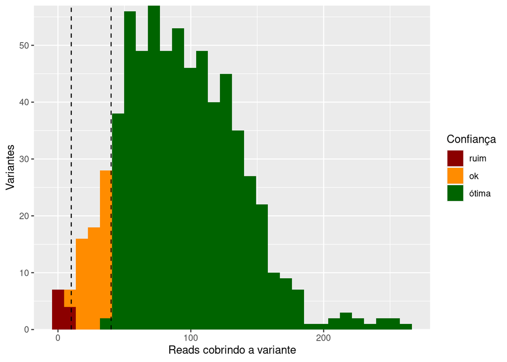

### Questão 2:

*Discorra sobre as regiões com baixa cobertura e quais foram seus critérios.* *Figuras são bem-vindas. Para a questão 2 deverá ser enviado um BED, contendo as regiões não cobertas.*

#### Qualidade de mapeamento por região do chr22

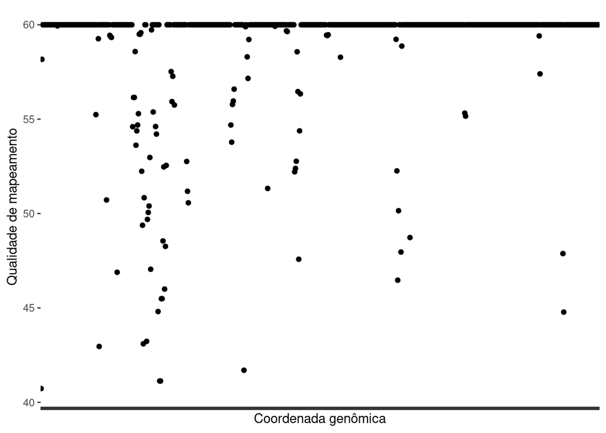

Eis a contagem das variantes encontradas considerando o número de reads:

```
##
##    ok ótima  ruim
##    63   609    11
```

**As regiões não cobertas pelo sequenciamento podem ser encontradas em: coverage_complement.bed**

### Questão 3: Obter informações sobre seu alinhamento.

*Quantos reads? Qual a porcentagem deles que foi mapeada corretamente?*

**Resposta: 1810534 reads sendo 1809243 reads mapeadas corretamente, o que corresponde a 99.93%.**

*Muitos alinharam em mais de um local do genoma com a mesma qualidade?*

**Resposta: 584 reads (0.03%)**

*Para a terceira questão deverá ser enviado um arquivo TSV, com as colunas “nreads” (número de reads usados), “proper_pairs” (pares mapeados corretamente), “mapQ_0” (número de reads com qualidade de mapeamento == 0)*

**Resposta: Vide questao3.tsv**